# WeRateDogs Rating System

*An attempt to explore and analyze WeRateDogs System*

*Author: Amnah Samkari*

```python
import pandas as pd
import matplotlib.pyplot as plt

df = pd.read_csv('twitter_archive_master.csv')
```

## Introduction

The dataset that we visualizing is a mainly a tweet archive of Twitter user @dog_rates, also known as WeRateDogs. WeRateDogs is a Twitter account that rates people's dogs with a humorous comment about the dog. These ratings almost always have a denominator of 10. The numerators, though? Almost always greater than 10. 11/10, 12/10, 13/10, etc. Why? Because "they're good dogs Brent." WeRateDogs has over 4 million followers and has received international media coverage.  
Here we will try to explore these ratings more, and try to get some sense of it, and are they related to dogs breeds.

## Analysis

First, let us see check the rating over all, finding numbers like the mean, media, maximum and minimum.

```python
df['rating_numerator'].describe()
```

```
count    1993.000000
mean       11.650166
std        40.649048
min         0.000000
25%        10.000000
50%        11.000000
75%        12.000000
max      1776.000000
Name: rating_numerator, dtype: float64
```

The results we can see for our 1993 records seems a little strange, because we can see the percentiles are close to each other, but the std is 40, which is unacceptable. Perhaps it is the effect of the max 1776 rating (clearly an outlier) So let's visualize the data to get a better scene.

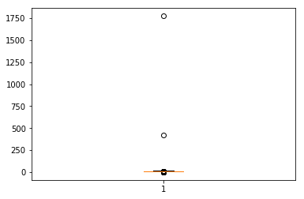

```python
plt.boxplot(df['rating_numerator']);
```

It is now clear how 2 great outliers affected the results we obtained previously, so lets visualize the ratings again without these outliers.

```python
df[df['rating_numerator'] < 15]['rating_numerator'].describe()
```

```
count    1991.000000
mean       10.558905
std         2.175766
min         0.000000
25%        10.000000
50%        11.000000
75%        12.000000
max        14.000000
Name: rating_numerator, dtype: float64
```

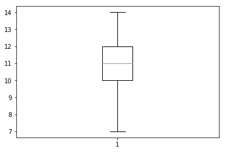

```python
plt.boxplot(df['rating_numerator'], showfliers = False);
```

Now its much better, and it is clearer what are the ratings normally are. A dog might on average get a rating between 12 and 10, the highest rating a dog ever had was 14. We can observe that most the ratings are 10 and above, but some are below, and thats due to the fact that this account used to rate normally, than they shifted to their new rating system.

Ok now lets check the different breeds of dogs that had been rated.

```python
# Dogs breed count
df.groupby('breed')['tweet_id'].count()
```

```
breed
Chihuahua                  9
French_bulldog           247
Old_English_sheepdog      97
Pembroke                   1
Samoyed                    2
Unknown                    1
chow                    1214
dalmatian                274
komondor                 148
Name: tweet_id, dtype: int64
```

```python
# Dogs breed percentages
df.groupby('breed')['tweet_id'].count()/sum(df.groupby('breed')['tweet_id'].count())*100
```

```
breed
Chihuahua                0.451581
French_bulldog          12.393377
Old_English_sheepdog     4.867035
Pembroke                 0.050176
Samoyed                  0.100351
Unknown                  0.050176
chow                    60.913196
dalmatian               13.748118
komondor                 7.425991
Name: tweet_id, dtype: float64
```

As we can see, almost 61% of all dogs rated are descendant from Chow, while most of the other types found are less than 15% like the Dalmation, French Bulldog, Komondor and the Old English Shepperd and others less than 1% like the Chihuahua, Pembroke and Samoyed.

Now I am curious to know whether the dog's breed could affect its rating somewhat, lets check it out.

```python
df.groupby('breed')['rating_numerator'].describe()
```

| breed | count | mean | std | min | 25% | 50% | 75% | max |
| --- | --- | --- | --- | --- | --- | --- | --- | --- |
| Chihuahua | 9.0 | 12.888889 | 0.600925 | 12.0 | 13.0 | 13.0 | 13.0 | 14.0 |
| French_bulldog | 247.0 | 12.459514 | 1.175798 | 0.0 | 12.0 | 13.0 | 13.0 | 14.0 |
| Old_English_sheepdog | 97.0 | 12.309278 | 0.905548 | 10.0 | 12.0 | 12.0 | 13.0 | 14.0 |
| Pembroke | 1.0 | 13.000000 | NaN | 13.0 | 13.0 | 13.0 | 13.0 | 13.0 |
| Samoyed | 2.0 | 13.000000 | 0.000000 | 13.0 | 13.0 | 13.0 | 13.0 | 13.0 |
| Unknown | 1.0 | 13.000000 | NaN | 13.0 | 13.0 | 13.0 | 13.0 | 13.0 |
| chow | 1214.0 | 11.795931 | 52.064889 | 0.0 | 9.0 | 10.0 | 11.0 | 1776.0 |
| dalmatian | 274.0 | 11.580365 | 1.227502 | 3.0 | 11.0 | 12.0 | 12.0 | 14.0 |
| komondor | 148.0 | 8.689189 | 2.536405 | 1.0 | 8.0 | 9.0 | 10.0 | 13.0 |

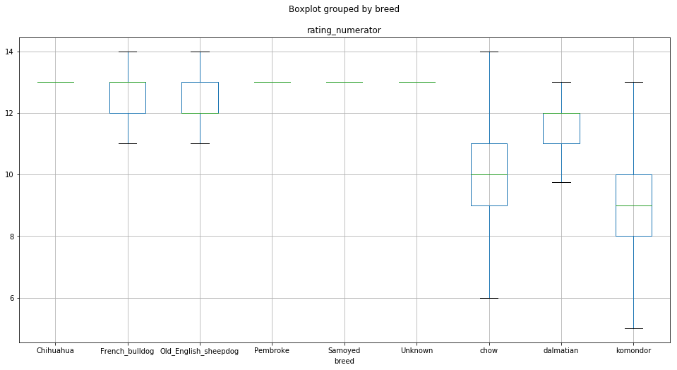

```python
# Create box plots
df.boxplot(column='rating_numerator', by='breed', showfliers=False, figsize=(16,8));
```

Hmmm, apparently some breeds, and duo to the lack of data, showed as lines instead of boxes, so it is not enough to judge, but for the other types appearing in boxes, we can sense that Bulldogs and sheepdogs are more likely to get a rating above 12, while the 61% of our Chow dogs, normally fall between 11 and 9. A Komondor dog will most probably get a lower rating than the rest of the dogs

## Conclusion

WeRateDog account even though it seems that it relays only on the dog's picture, but it somewhat suggested that the dogs breed might play a role in rating a dog.  
That data obtained is not enough to draw a more accurate suggestion, in addition the these dogs breeds might not be 100%, therefore, the more the data with more reliable information about the dogs breed might give better conclusion.